# Interpolation Methods

Caleb Koch

August 2016

This is a brief document summarizing the work that I’ve done over the summer. Crystal requested that I do something like this before writing a formal article (which I will be working on after this). It essentially provides an overview of how interpolation methods were identified and how they were tested. Some of the results are also presented. The formal write-up will include more detailed explanations of a lot of the techniques presented here.

## Objective

The objectives of the project included

1. Finding interpolation methods that yielded more accurate results than that of linearly interpolated trajectories
2. Determining best stage of preprocessing to apply interpolation
3. Creating a framework from which interpolation methods can be assessed and compared

## Notes and Remarks on Potential Interpolation Methods

The paper *A stable and fast implementation of natural neighbor interpolation* by Liang & Hale (2010) does a good job articulating an important distinction that should be made when considering various interpolation methods. Specifically, the authors note that some interpolation methods use scattered data. These types of interpolants accept pairs of the form $(\mathbf{x}_i, f_i)$ for $i=\{1,2,...\}$ such that $\mathbf{x}_i \in \mathbb{R}^n$ is a n-tuple and $f_i\in \mathbb{R}$ is the corresponding real value. Typically, this data would represent some characteristic of a multidimensional surface (for example, rainfall values over a mapped area). Hence these particular interpolating methods (i.e. ones that rely on scattered data input) wouldn’t work well with trajectory data.

### Barnes Interpolation

Not appropriate for trajectory or time series data since it typically interpolates an atmospheric variable in the form $f(x,y)$. Typically $f$ gives some parameter which can be used with coordinates $x,y$ to create an contour plot.

### Spline Interpolation

This method includes linear and cubic spline interpolation. It can be applied to both the time series and trajectory data.

### Polynomial Interpolation

This method can be used on trajectory and time series data.

### Bilinear

Conventionally, bilinear interpolation would not be used with trajectory or time series data; however, the principle behind it (performing linear interpolation in both directions) could be adapted to compute interpolants on the desired datasets.

### Kriging

Kriging is used when the data reflects output fitted to a particular map. It would be used for reasons similar to that of Barnes interpolation.

### Principal Curve Detection

This method would work best with a “data cloud” through which one constructs an optimal curve. Hence the format of the trajectory data makes it difficult to use with principal curve detection.

### Frequent Trajectory Mining

This method is outlined in the paper *Frequent Trajectory Mining on GPS Data* (2010) by Savage et al. It could be appropriately applied to trajectory data; however, the algorithm would have to be reconstructed since it doesn’t seem the authors have published any code related to their study.

### Neural Network/Machine Learning and Probabilistic Modeling

These methods stand as potential means of interpolating trajectory data.

### Nearest Neighbor

This method can be applied to both time series and trajectory data.

### Natural Neighbor

This method relies on an implementation of a Voronoi diagram. If one of these diagrams can be constructed from the dataset then natural neighbor interpolation can be performed. This works best with scattered data.[^1]

### Inverse Distance Weighting

This method also applies to scattered data. It is similar to natural neighbor interpolation in that it implements a weighting procedure.

### Latent Statistical Model

*GPS Trajectory Data Enrichment Based on a Latent Statistical Model* (2016) by Kinoshita et al. outlines the latent statistical model. The model estimates the mode of transportation at various parts of the trajectory and uses such information to yield more accurate interpolations. Their experimental results report a 78% accuracy. So, this may be a potential method to implement; however, it does not seem that the authors have published any code accessible to the public. Nonetheless, their paper includes ample detail regarding model construction to build a separate implementation.

### Local regression (LOESS)

This method can work with both time series and trajectory data.

## Experimentation

Each interpolation method was tested on a total of 4,000 trajectories. Initially, I selected 100 unique trajectories from the GeoLife dataset. These trajectories are listed below by their filenames and associated file size. The trajectories were intentionally selected to represent a range of file sizes.

```
##     File               Size (KB)
## 1   20081026081229.plt  203.7949
## 2   20081031232033.plt  215.9160
## 3   20081025010205.plt  227.8887
## 4   20081206035334.plt  230.0449
## 5   20090127012158.plt  230.9326
## 6   20081122023300.plt  232.1484
## 7   20090128072557.plt  234.1123
## 8   20081001225205.plt  252.4590
## 9   20081109031933.plt  286.7744
## 10  20081114001504.plt  290.3438
## 11  20081024000805.plt  299.4229
## 12  20090612220336.plt  301.8906
## 13  20090129053303.plt  304.6885
## 14  20090131002206.plt  345.5342
```

[output cut: 86 more lines]

A gap was created for each unique trajectory by removing a certain number of points. The number of removed points was a part of the sequence 50, 100, …, 2000. Thus, 40 artificial trajectories resulted from each original trajectory (one for each gap length). At this point, I could linearize the trajectories using the Hilbert space-filling curve, leading to a second dataset. The distinction between time series and trajectory data helped to satisfy the second objective of this project. Each interpolation method (cubic spline, linear, local regression, nearest neighbor, and polynomial) was applied to each file in the trajectory dataset and the time series dataset. An error analysis on the resulting files returned an inaccuracy value which allowed for cross-analysis.

### Error Analysis

The error analysis involves two datasets (i.e. trajectories or time series): the original dataset, denoted $t$, and the interpolated dataset, denoted $t'$. If $p_i, p_{i+1} \in t$ are consecutive points in the original dataset and $p_i' \in t'$ is a point in the interpolated dataset then the standard error, $e_s$ is given by
$$e_s = \frac{\sum d(p_i, p_i')}{\sum d(p_i, p_{i+1})}$$
where $d()$ returns the Euclidian distance between two points. Note that $e_s$ is unitless because the units of the quantities $\sum d(p_i, p_i')$ and $\sum d(p_i, p_i')$ cancel each other. The comparative analysis between interpolation methods is possible from the value returned by $e_s$.

## Results

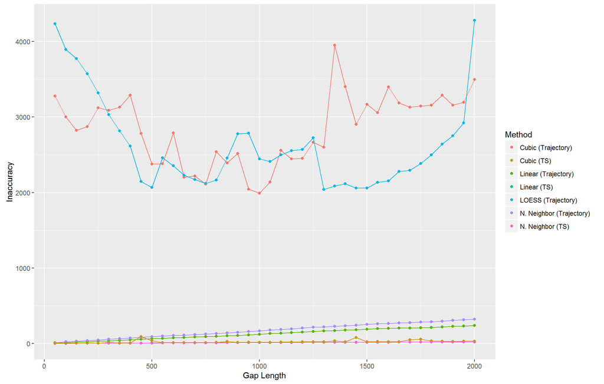

After calculating the standard error for each file, I grouped the data according to gap length (so, each gap length had 100 error values associated with it) and then took the average of each group.

[interactive chart not shown]

[^1]: Hence, it wouldn’t work well with trajectory data